# Simple data visualization

# Introduction

R provides very powerful tools for data visualization, particularly `ggplot`. This leads to a dilemma when teaching, however. Do we first teach the basics or `ggplot` *before* students can visualize their data, or do we use other simpler tools for summarization and visualization, albeit of a limited kind, and later teach more about the powerful `ggplot` tools? The `psyntur` package aims to provide some tools if the latter approach is taken. These functions aim to make it quick and easy to perform the common kinds of data exploration and visualization. All functions, however, are wrappers around sets of `ggplot` commands In this vignette, we showcase some of these tools.

The required functions as well as some example psychological science data sets can be loaded with the usual `library` command.

```r
library(psyntur)
```

# Scatterplots

We can perform a standard 2d scatterplot with `scatterplot`. For example, using the `faithfulfaces` data provided by `psyntur`, we can plot a scatterplot showing the relationship between the perceived (sexual) faithfulness of a person in a photo against their perceived trustworthiness as follows.

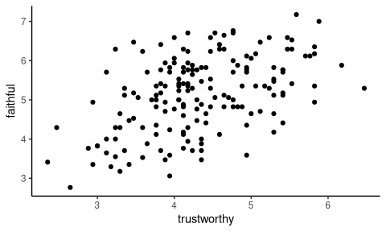

```r
scatterplot(x = trustworthy, y = faithful, data = faithfulfaces)
```

We can colour code the points according to the value of a third, usually categorical variable, by using the `by` argument. For example, here we colour code the points according to the sex of the person in the photo.

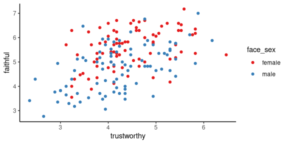

```r
scatterplot(x = trustworthy, y = faithful, data = faithfulfaces, by = face_sex)
```

We can add the line of best fit to all points in the scatterplot, or to each set of coloured points in the scatterplot if `by` is used, with the `best_fit_line` argument.

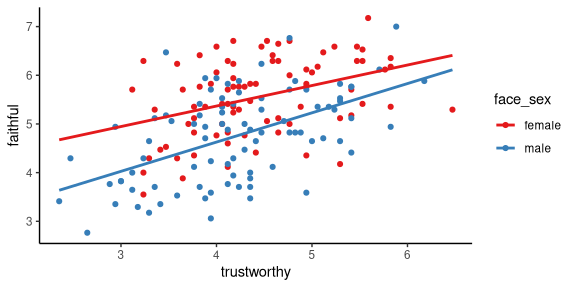

```r
scatterplot(x = trustworthy, y = faithful, data = faithfulfaces,
            by = face_sex, best_fit_line = TRUE)
```

# Boxplots

Boxplots, also known as box-and-whisker plots, or Tukey boxplots or box-and-whisker plots, display the distributions of univariate data, optionally grouped according to other variables. For example, to show a boxplot of the distribution of all the response times in an experiment that collected response times in different conditions, which is provided by the `vizverb` data sets, we can do the following.

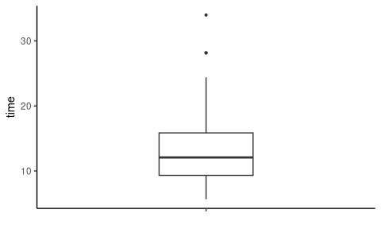

```r
tukeyboxplot(y = time, data = vizverb)
```

We can add all the points as jittered points as follows.

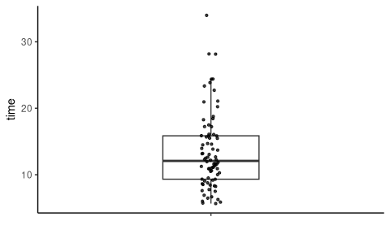

```r
tukeyboxplot(y = time, data = vizverb, jitter = TRUE)
```

If we want to plot the distribution of `time` for each of the two different tasks performed in the experiment, provide by the `task` variable in `vizverb`, we can set the `x` variable to `task` as follows.

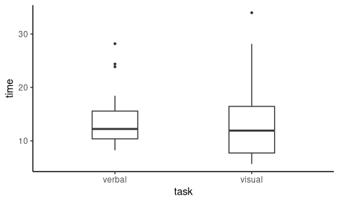

```r
tukeyboxplot(y = time, x= task, data = vizverb)
```

The `vizverb` data is from a two-way factorical experiment where reaction times are collected for different tasks (the `task` variable) and using different responses (the `response` variable). We can plot the distribution of `time` according to both `task` and `response` by using `x` and `by` together as follows.

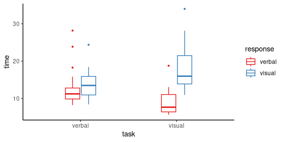

```r
tukeyboxplot(y = time, x= task, data = vizverb, by = response)
```

Jittered points can be put on these plots by using `jitter = TRUE`.

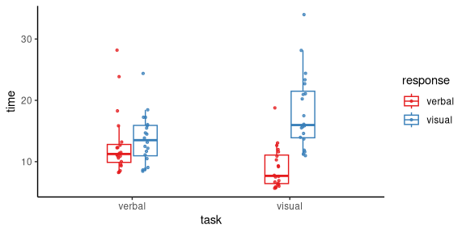

```r
tukeyboxplot(y = time, x= task, data = vizverb,
             by = response, jitter = TRUE)
```

Continuous variables can be used as the `x` variable as in the following example using the R built in `ToothGrowth` data set.

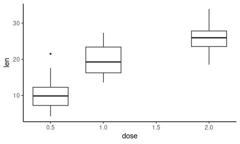

```r
tukeyboxplot(y = len, x = dose, data = ToothGrowth)
```

This can be used with `by` and `jitter` too.

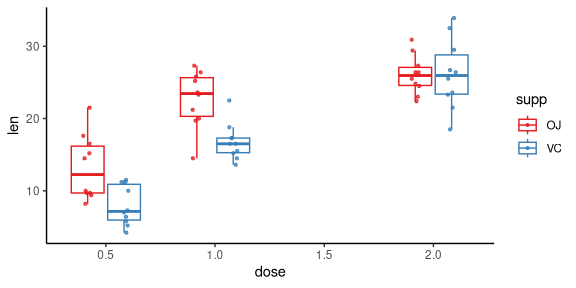

```r
tukeyboxplot(y = len, x = dose, data = ToothGrowth,
             by = supp, jitter = TRUE, jitter_width = .5)
```

# Histograms

Histograms can be made with the `histrogram` function. For example, to plot the onset ages of schizophrenia, using the `schizophrenia` data, we can do the following.

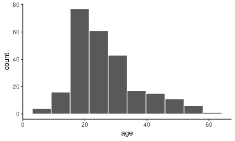

```r
histogram(x = age, data = schizophrenia)
```

We can change the number of bins from its default of 10 with the `bins` argument.

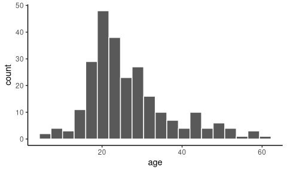

```r
histogram(x = age, data = schizophrenia, bins = 20)
```

If we use a grouping variable, such as the `gender` variable, using the `by` argument, we obtain a stacked histogram.

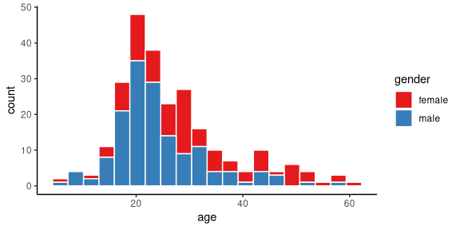

```r
histogram(x = age, data = schizophrenia, by = gender, bins = 20)
```

When using `by`, we can obtain *dodged* rather than stacked histograms by setting `position = 'dodge'` as in the following example.

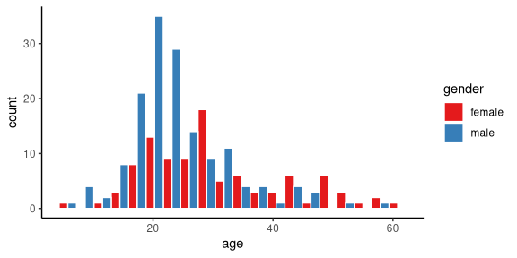

```r
histogram(x = age, data = schizophrenia,
          by = gender, bins = 20, position = 'dodge')
```

Likewise, we can obtain overlapping histograms by setting `position = 'identity'` as in the following example.

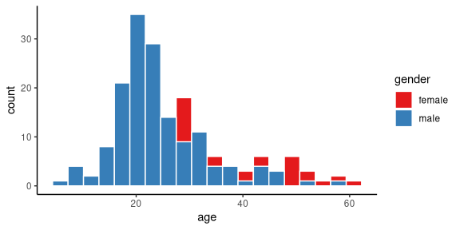

```r
histogram(x = age, data = schizophrenia,
          by = gender, bins = 20, position = 'identity')
```

In the case of `position = 'identity'`, it is usually required to make the bars transparent by setting the `alpha` value to be less than 1.0, as in the following example.

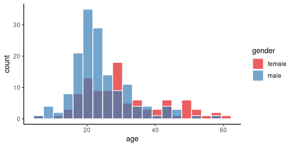

```r
histogram(x = age, data = schizophrenia,
          by = gender, bins = 20, position = 'identity', alpha = 0.7)
```